# RK_Application 1 (Week 6): Data Processing (ESDS I)

Rohit Koonireddy

2023-10-24

```r
require(lubridate)
require(tidyverse)
require(ncdf4)
require(viridis)
require(raster)
require(rworldmap)
require(EFDR)
library(RColorBrewer)
```

In this application we will work through the topics covered in the first part of the ESDS course, focussing on data set exploration, simple visualisation, application of various functions on the data set, and the use of good coding practices in R.

# 1. Basic data set investigation in R

*a)* Read in the Carbon Tracker dataset “CT2017.molefrac_glb3x2_2000-01.nc”, which is a gridded data set of mean monthly carbon dioxide mixing ratio for January 2000 produced by NOAA’s Carbon Tracker program. For more information about Carbon Tracker, see the website: https://gml.noaa.gov/ccgg/carbontracker/.

```r
# Add code here
carbon_tracker_nc = nc_open('data/CT2017.molefrac_glb3x2_2000-01.nc')
```

*b)* What variables (and what are their units) and dimensions (and what size are they) are present in this data set?

**Variables**: *add vars* There are 12 variables [with their dimensions in the square brackets] in the ncdata file given, : 1. air_mass[longitude,latitude,level,time] 2. blh[longitude,latitude,time] 3. co2[longitude,latitude,level,time] - _FillValue: -9.99999979021477e+33 4. decimal_date[time] - _FillValue: -1e+34 5. gph[longitude,latitude,boundary,time] _FillValue: -9.99999979021477e+33 6. orography[longitude,latitude] 7. pressure[longitude,latitude,boundary,time] _FillValue: -9.99999979021477e+33 8. specific_humidity[longitude,latitude,level,time] 9. temperature[longitude,latitude,level,time] 10.time_components[calendar_components,time] 11.u[longitude,latitude,level,time] 12.v[longitude,latitude,level,time]

**Dimensions**: *add dimensions* There are 6 dimensions and the size of each is given here 1. time Size:1 2. level Size:25 3. latitude Size:90 4. longitude Size:120 5. boundary Size:26 6. calendar_components Size:6

*c)* Save longitude, latitude, decimal_date and co2 as vectors/matrices.

```r
lon <- ncvar_get(carbon_tracker_nc, "longitude")
lat <- ncvar_get(carbon_tracker_nc, "latitude")
dec_data <- ncvar_get(carbon_tracker_nc, "decimal_date")
co2_data <- ncvar_get(carbon_tracker_nc, "co2")
level <- ncvar_get(carbon_tracker_nc, "level")
```

- Get the fill value for CO2 and use it to replace missing values with NaN.

```r
# Add code here
fillvalue_co2 <- ncatt_get(carbon_tracker_nc, "co2", "_FillValue", verbose="F")
print(paste0("Fill value for co2:",fillvalue_co2))
```

```
## [1] "Fill value for co2:TRUE"
## [2] "Fill value for co2:-9.99999979021477e+33"
```

```r
#no missing values but still I create a replace statement
co2[co2==fillvalue_co2$value] = NaN
```

- If needed, convert units of longitude and latitude to degrees. I do not convert them into degrees as they are already in degrees.
- Close the nc file and combine all the variables to a list.

```r
co2_list = list(lat=lat,lon=lon,decimal_date=dec_data,level = level, co2=co2_data)
nc_close(carbon_tracker_nc)
```

*d)* Make two figures, one showing a global map of CO2 at the surface level, and one showing CO2 at the highest atmospheric level available in this dataset.

- Make sure the plots show continental outlines and have titles.
- You can convert to a raster like we did in an earlier exercise or use other plotting methods you find online.
- If you can, create a function to transform and plot the data and add the continental outlines. Then you can use this function on the two atmospheric levels efficiently.

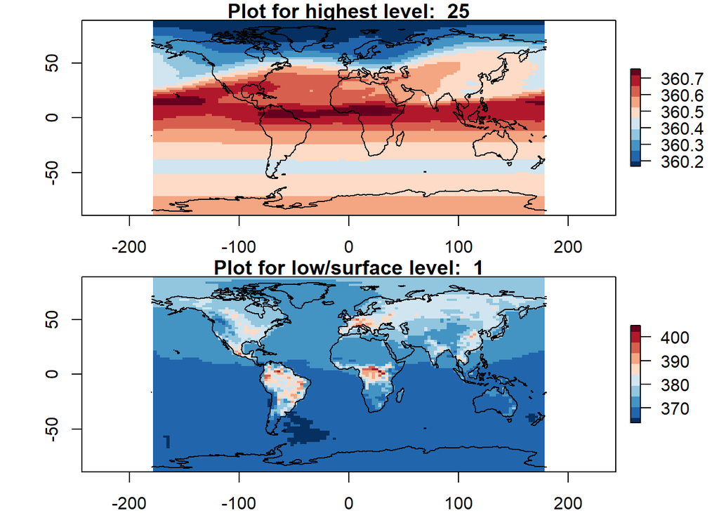

```r
library(sf)
library(raster)


# Add code here
plot_map = function(lon, lat, data, local_level = NULL, ylim = c(-90, 90), xlim = c(-180, 180), cmap = rev(brewer.pal(10, "RdBu")), title = "Plot") {
  if (is.null(local_level) || local_level == "HIGH") {
    #print("Choosing the highest level")
    local_level <- max(data$level)
    data <- data$co2[, , local_level]
    title = paste("Plot for highest level: ", local_level)
  } else if (local_level == "LOW") {
    #print("Choosing the lowest level")
    local_level <- min(data$level)
    data <- data$co2[, , local_level]
    title = paste("Plot for low/surface level: ", local_level)
  } else {
    print("Invalid local_level. Choose either 'HIGH' or 'LOW'.")
  }

  r = raster(t(data), xmn = min(lon), xmx = max(lon), ymn = min(lat), ymx = max(lat), crs = CRS("+proj=longlat +ellps=WGS84 +datum=WGS84 +no_defs +towgs84=0,0,0"))
  r = flip(r, direction = 'y')
  plot(r, ylim = ylim, xlim = xlim, main = title, col = cmap)
  plot(coastsCoarse, add = TRUE, col = 'black')
}

# Call the plot_map function with local_level explicitly set to "HIGH" or "LOW" or leave it as NULL
par(mar = c(2, 4, 1, 1))  # set plotting margins
par(mfrow=c(2,1))
plot_map(co2_list$lon, co2_list$lat, data = co2_list, local_level = "HIGH")  # Set local_level as "HIGH" or "LOW" here
plot_map(co2_list$lon, co2_list$lat, data = co2_list, local_level = "LOW")  # Set local_level as "HIGH" or "LOW" here
```

[output not shown]

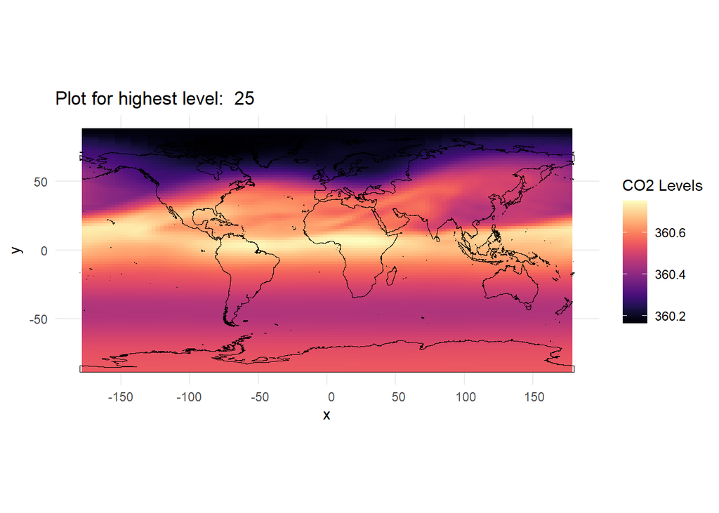

```r
#plot including continent lines
#download world_continents.shp file from ARCGIS

# Load the world coastlines shapefile
continent_data <- st_read("data/World_Continents.shp")
plot_map <- function(lon, lat, data, local_level = NULL, ylim = c(-90, 90), xlim = c(-180, 180), cmap = rev(brewer.pal(10, "RdBu")), title = "Plot") {
  if (is.null(local_level) || local_level == "HIGH") {
    print("Choosing the highest level")
    local_level <- max(data$level)
    data <- data$co2[, , local_level]
    title = paste("Plot for highest level: ", local_level)
  } else if (local_level == "SURFACE") {
    print("Choosing the SURFACE level")
    local_level <- min(data$level)
    data <- data$co2[, , local_level]
    title = paste("Plot for low/surface level: ", local_level)
  } else {
    print("Invalid local_level. Choose either 'HIGH' or 'SURFACE'.")
  }

   r = raster(t(data), xmn = min(lon), xmx = max(lon), ymn = min(lat), ymx = max(lat), crs = CRS("+proj=longlat +ellps=WGS84 +datum=WGS84 +no_defs +towgs84=0,0,0"))
  r = flip(r, direction = 'y')
  r_df <- as.data.frame(r, xy = TRUE)

ggplot(data = r_df) +
  geom_raster(aes(x = x, y = y, fill = layer)) +
  scale_fill_viridis(option = "magma", name = "CO2 Levels") +
  geom_sf(data = continent_data, fill = NA, color = "black") +
  labs(title = title) +
  theme_minimal()
}

# Call the plot_map function with local_level explicitly set to "HIGH" or "LOW" or leave it as NULL
par(mar = c(2, 4, 1, 1))  # set plotting margins
par(mfrow = c(2, 1))
plot_map(co2_list$lon, co2_list$lat, data = co2_list, local_level = "HIGH")
```

[output not shown]

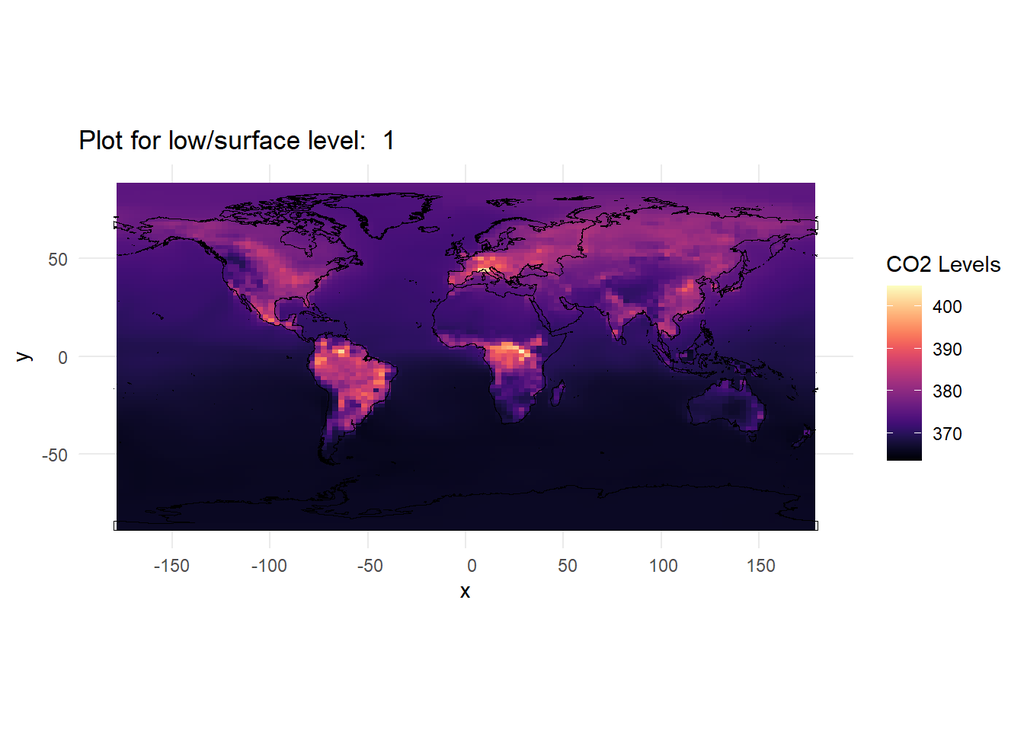

```r
plot_map(co2_list$lon, co2_list$lat, data = co2_list, local_level = "SURFACE")
```

# 2. Exploratory statistics

*a)* Write a function to summarise CO2 in a certain layer according to latitude band.

- The function should output a dataframe, with rows corresponding to each latitude band and columns to different variables.
- The dataframe should have variables min_lat and max_lat, which show the latitude range of the band, as well as mean, median, mode and standard deviation of CO2 in the band.
- You should provide the function with data from a certain layer, the latitude vector or matrix, and the desired latitude binning band width (this is the function input).
- The latitude band width should be an optional input, with a default that latitude bands should be 10 degrees wide, eg. -90 to -80, -80 to -70, and so on.
- You will also need to write an extra function to calculate the mode. You will need to discretise the continuous data to be able to find a mode. How many decimal places seems appropriate to discretise the CO2 data?

*Extra info:*

The function should look like:

```r
summarise_co2_by_lat = function(data,lat,...){
  #FUNCTION BODY
}
```

An example of the output:

min_lat max_lat mean median mode stdev  
1 -90 -80 366.3560 366.3762 366.4 0.04223515  
2 -80 -70 366.3108 366.3052 366.4 0.07199042  
3 -70 -60 366.1750 366.1820 366.2 0.11213171  
…

```r
# Function to calculate mode of a numeric vector
calculate_mode <- function(x, digits = 2) {
  x_rounded <- round(x, digits = digits)
  unique_x <- unique(x_rounded)
  tab <- table(x_rounded)
  mode_values <- unique_x[tab == max(tab)]
  return(mode_values)
}

# Function to summarize CO2 data by latitude bands
summarise_co2_by_lat <- function(data, lat, lat_band_width = 10, local_level= NULL) {
  # Create latitude bands
  min_lat <- seq(-90, 90 - lat_band_width, by = lat_band_width)
  max_lat <- min_lat + lat_band_width

  # Initialize empty vectors to store summary statistics
  mean_values <- vector("numeric", length(min_lat))
  median_values <- vector("numeric", length(min_lat))
  mode_values <- vector("numeric", length(min_lat))
  stdev_values <- vector("numeric", length(min_lat))

  # Loop through latitude bands and calculate statistics
  for (i in 1:length(min_lat)) {
    mask <- lat >= min_lat[i] & lat < max_lat[i]
    mask <- as.logical(mask)
    if (is.null(local_level)){
      co2_values <- data[,mask,]
    }else if (local_level== "HIGH"){
      co2_values <- data[,mask,25]
    }else if (local_level == "SURFACE"){
      co2_values <- data[,mask,1]
    }else{
      print("Make sure you are entering SURFACE or NULL")
    }

    mean_values[i] <- mean(co2_values)
    median_values[i] <- median(co2_values)
    mode_values[i] <- calculate_mode(co2_values)
    stdev_values[i] <- sd(co2_values)
  }

  # Create a dataframe with the summary
  summary_df <- data.frame(
    min_lat = min_lat,
    max_lat = max_lat,
    mean = mean_values,
    median = median_values,
    mode = mode_values,
    stdev = stdev_values
  )

  return(summary_df)
}

# Example usage
# Replace co2_data and lat_data with your data
# The default latitude band width is 10 degrees
result <- summarise_co2_by_lat(co2_list$co2, co2_list$lat, lat_band_width = 10)

# Print the result
print(result)
```

```
##    min_lat max_lat     mean   median   mode    stdev
## 1      -90     -80 364.8024 366.3322 366.31 2.326816
## 2      -80     -70 364.8164 366.2747 366.34 2.314326
## 3      -70     -60 364.8368 366.2157 366.00 2.290247
## 4      -60     -50 364.9699 366.2381 365.97 2.309727
## 5      -50     -40 365.1583 366.3308 366.04 2.341522
## 6      -40     -30 365.4584 366.6408 366.50 2.448372
## 7      -30     -20 365.9184 366.9892 366.82 2.483179
## 8      -20     -10 366.4717 367.3950 373.39 2.514600
## 9      -10       0 367.4146 368.2196 383.60 2.921068
## 10       0      10 368.1071 369.0788 370.35 3.289666
## 11      10      20 368.1260 369.3294 369.71 3.300176
## 12      20      30 368.3659 369.4744 371.77 3.922830
## 13      30      40 368.7065 370.1794 373.50 4.600844
## 14      40      50 369.0840 370.8546 375.69 5.261731
## 15      50      60 369.2529 371.1455 374.72 5.571352
## 16      60      70 369.2974 371.4089 377.96 5.736846
## 17      70      80 369.2099 371.6923 377.04 5.671718
## 18      80      90 369.1667 371.7272 375.26 5.563837
```

*b)* Run your function to summarise CO2 by latitude band for the surface and the uppermost layers (the layers you plotted earlier).

```r
# Add code here
#print("For upper most level:")
upper_lat_co2 <- summarise_co2_by_lat(co2_list$co2, co2_list$lat, lat_band_width = 10, local_level = "HIGH")

#print("For surface level:")
surface_lat_co2 <- summarise_co2_by_lat(co2_list$co2, co2_list$lat, lat_band_width = 10, local_level = "SURFACE")
```

*c)* Plot CO2 against latitude for the upper and surface layers, using the mean CO2 per latitude band.

- You saved the min and max lat of each band so you’ll need to find the mid-point of each band for plotting the latitude.
- Show the standard deviation in each latitude band shown with error bars. *Hint*: there is no built in error bars in base R plotting but you can use the arrows() function to make them, there are examples on google. Alternatively, use ggplot.
- Use a different colour to distinguish surface and upper layers and include them in different subplots.
- In different line styles, show also the median and mode.
- Include a legend and whatever else is needed to make your figure easy to understand.

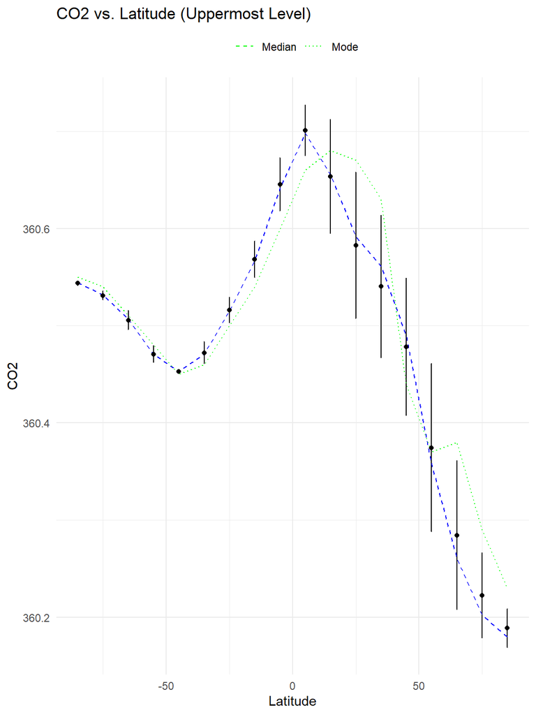

```r
# Load necessary libraries if not already loaded
library(ggplot2)

# Plot for the uppermost level
ggplot(upper_lat_co2, aes(x = (min_lat + max_lat) / 2, y = mean, ymin = mean - stdev, ymax = mean + stdev)) +
  geom_errorbar(width = 0.1) +
  geom_line(aes(y = median, linetype = "Median"), color = "blue") +
  geom_line(aes(y = mode, linetype = "Mode"), color = "green") +
  geom_point() +
  labs(title = "CO2 vs. Latitude (Uppermost Level)", x = "Latitude", y = "CO2") +
  scale_color_manual(values = c("Mean" = "black")) +
  scale_linetype_manual(values = c("Mean" = "solid", "Median" = "dashed", "Mode" = "dotted")) +
  theme_minimal() +
  theme(legend.title = element_blank()) +
  theme(legend.position = "top")
```

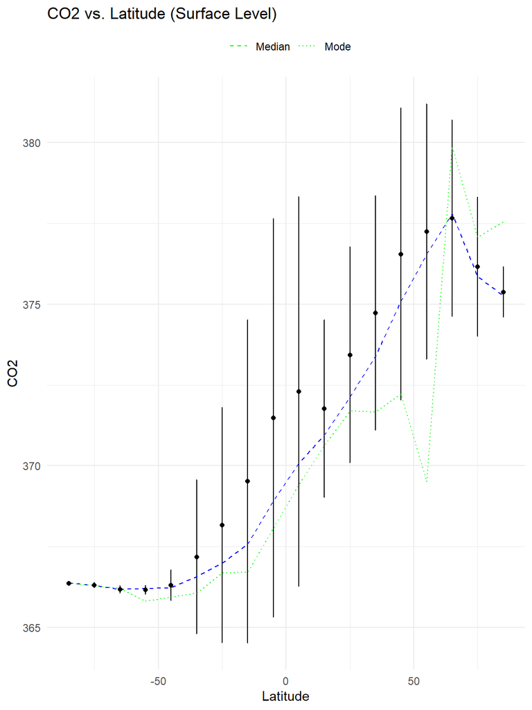

```r
# Plot for the surface level
ggplot(surface_lat_co2, aes(x = (min_lat + max_lat) / 2, y = mean, ymin = mean - stdev, ymax = mean + stdev)) +
  geom_errorbar(width = 0.1) +
  geom_line(aes(y = median, linetype = "Median"), color = "blue") +
  geom_line(aes(y = mode, linetype = "Mode"), color = "green") +
  geom_point() +
  labs(title = "CO2 vs. Latitude (Surface Level)", x = "Latitude", y = "CO2") +
  scale_color_manual(values = c("Mean" = "black")) +
  scale_linetype_manual(values = c("Mean" = "solid", "Median" = "dashed", "Mode" = "dotted")) +
  theme_minimal() +
  theme(legend.title = element_blank()) +
  theme(legend.position = "top")
```

*d)* What do you observe from this figure and from the maps in the previous step?

*Observations* From the figure showing CO2 levels against latitude for both the uppermost and surface levels, and the maps created in the previous step, we can make the following observations:

Uppermost vs. Surface Levels: Comparing the two subplots, we can observe that the uppermost level generally has lower CO2 levels than the surface level. This difference may be attributed to the vertical distribution of CO2 in the atmosphere, with higher concentrations at the surface.

Influence of Latitude: The variation of CO2 with latitude highlights the influence of geographical location on CO2 concentrations. This observation is consistent with the fact that CO2 levels can vary due to factors such as proximity to emission sources, atmospheric circulation patterns, and seasonal changes. # 3. Downscaling

*a)* Read in the CO2 timeseries from Mauna Loa that we used in the first tutorial: “co2_mlo_surface-insitu_2_3001-9999_daily.txt”

- Make sure all missing or invalid values are represented as NaNs.

```r
# Add code here
importdata <- function(station) {
  # Get the data
  file = paste0("data/co2_",station,"_surface-insitu_2_3001-9999_daily.txt")
  data = read.delim(file,sep = " ", comment.char = '#')
  # Fix timestamp
  date = paste(data$year,data$month,data$day,sep="-")
  time = paste(data$hour,data$minute,data$second,sep=":")
  data$dt = ymd_hms(paste(date,time,sep=" "))
  # Replace missing with NaN
  data$value[data$value<0] = NaN
  # Find annual means
  ann_means = aggregate(data$value, list(data$year), FUN=mean, na.rm=TRUE)
  colnames(ann_means) = c("year","value")
  # Detrend
  data$value_detrended = data$value*NaN # create space for detrended data
  for (n in seq_along(ann_means$year)){ # Use a while loop to run through all the years
    tmp = data$year==ann_means$year[n]
    data$value_detrended[tmp] = data$value[tmp] - ann_means$value[n]
  }
  # Create a list with our outputs
  result = list(data=data,ann_means=ann_means)
  return(result)
}
# This function outputs a list containing the data and the annual means for the desired station
mlo = importdata("mlo")
```

*b)* In the Data folder, there are 6 Carbon Tracker data files (including the one we already used). Open each CT data file and find the CO2 value for the grid cell closest to Mauna Loa, for each of the first 20 levels.

- The longitude and latitude for Mauna Loa are in the mlo data file header.
- Save the 6 x 20 CO2 values (6 files/dates x 20 levels) and the 6 dates (decimal year) in a data frame.

To help you we provided the following code that you need to complete:

```r
# Define the latitude and longitude of Mauna Loa
mlo_latlon = c(19.536, -155.576)

# Find all CT2017 files in the "data" directory
files <- list.files("data", pattern = "CT2017.molefrac")

# Create an empty dataframe to store the results
ct_mlo <- data.frame(matrix(nrow = length(files), ncol = 26))
colnames(ct_mlo) <- c("date", paste0("co2_", 1:25))

# Loop through each of the files
for (n in seq_along(files)) {
  # Open the NetCDF file
  nc_data <- nc_open(paste0("data/", files[n]))

  # Extract the date (decimal year) from the file
  ct_mlo$date[n] <- ncvar_get(nc_data, "decimal_date")

  # Get latitude and longitude variables
  lat <- ncvar_get(nc_data, "latitude")
  lon <- ncvar_get(nc_data, "longitude")

  # Find the index of the closest grid cell to Mauna Loa
  lat_index <- which.min(abs(lat - mlo_latlon[1]))
  lon_index <- which.min(abs(lon - mlo_latlon[2]))

  # Extract CO2 values for the first 20 levels
  co2 <- ncvar_get(nc_data, "co2")
  ct_mlo[n, paste0("co2_", 1:25)] <- co2[lon_index, lat_index, 1:25]

  # Close the NetCDF file
  nc_close(nc_data)
}

library(lubridate)

decimal_to_formatted_date <- function(decimal_date) {
  year <- as.integer(decimal_date)
  day_of_year <- as.integer((decimal_date - year) * 365)  # Assuming a non-leap year
  date_in_date_format <- as.Date(paste(year, day_of_year), format = "%Y %j")
  date_in_formatted_format <- format(date_in_date_format, format = "%Y-%m-%d")
  return(date_in_formatted_format)
}

#convert the date
ct_mlo$date <- sapply(ct_mlo$date, decimal_to_formatted_date)
ct_mlo$date <- as.POSIXct(ct_mlo$date, format = "%Y-%m-%d")

print(head(ct_mlo))
```

```
##         date    co2_1    co2_2    co2_3    co2_4    co2_5    co2_6    co2_7
## 1 2000-01-15 371.0571 371.0560 371.0533 371.0418 370.9942 370.8838 370.6424
## 2 2002-07-15 372.7139 372.7116 372.7131 372.7300 372.8366 373.1052 373.6978
## 3 2005-01-15 379.2242 379.2190 379.2109 379.1807 379.1043 378.9781 378.7837
## 4 2007-07-15 383.8185 383.8156 383.8148 383.8186 383.8492 383.9557 384.2476
## 5 2010-01-15 389.9772 389.9706 389.9645 389.9510 389.9052 389.8256 389.4841
## 6 2012-07-14 393.2220 393.2203 393.2209 393.2295 393.2810 393.4143 393.7033
##      co2_8    co2_9   co2_10   co2_11   co2_12   co2_13   co2_14   co2_15
## 1 370.2778 370.0768 369.9792 369.8806 369.7096 369.5340 369.4074 369.2497
## 2 374.0993 374.0321 373.8382 373.7610 373.5887 373.4556 373.3054 373.3177
## 3 378.6372 378.5724 378.4626 378.3854 378.3175 378.3225 378.3431 378.2989
## 4 384.3849 384.2798 384.1663 384.0900 384.0159 383.9813 383.9851 383.9775
## 5 388.9824 388.8729 388.7650 388.5939 388.3954 388.2155 388.1184 388.0309
## 6 394.1771 394.3434 394.3630 394.3098 394.2494 394.1728 394.0589 394.0586
##     co2_16   co2_17   co2_18   co2_19   co2_20   co2_21   co2_22   co2_23
## 1 368.9465 368.5196 367.9437 366.7122 365.2826 364.0827 362.6842 361.6185
## 2 373.3944 373.4331 373.4621 372.6666 370.0063 367.2599 365.4480 365.0856
## 3 378.1913 378.0125 377.5437 376.0358 374.2607 372.7887 370.8877 369.4256
## 4 384.0244 384.0546 383.9200 382.9403 379.9483 376.7755 375.0240 374.4595
## 5 387.9262 387.8308 387.5118 386.0182 384.4515 382.5981 380.3429 378.7710
## 6 394.0469 393.9232 393.8333 392.6833 389.8528 387.0894 385.4818 384.8077
##     co2_24   co2_25
## 1 361.4600 360.7248
## 2 365.2790 364.6514
## 3 369.2505 368.7894
## 4 373.9835 372.9232
## 5 378.2872 377.4754
## 6 384.2957 383.0158
```

```r
mlo_df <- data.frame(mlo[1])
mlo_df <- mlo_df[c("data.site_gaw_id","data.dt","data.value","data.value_unc","data.latitude","data.longitude","data.altitude","data.elevation","data.intake_height")]
print(head(mlo_df))
```

```
##   data.site_gaw_id    data.dt data.value data.value_unc data.latitude
## 1              MLO 1973-01-01        NaN       -999.999        19.536
## 2              MLO 1973-01-02        NaN       -999.999        19.536
## 3              MLO 1973-01-03        NaN       -999.999        19.536
## 4              MLO 1973-01-04        NaN       -999.999        19.536
## 5              MLO 1973-01-05        NaN       -999.999        19.536
## 6              MLO 1973-01-06        NaN       -999.999        19.536
##   data.longitude data.altitude data.elevation data.intake_height
## 1       -155.576          3437           3397                 40
## 2       -155.576          3437           3397                 40
## 3       -155.576          3437           3397                 40
## 4       -155.576          3437           3397                 40
## 5       -155.576          3437           3397                 40
## 6       -155.576          3437           3397                 40
```

```r
mlo_df_2 <- data.frame(mlo[2])
print(head(mlo_df_2))
```

```
##   ann_means.year ann_means.value
## 1           1973             NaN
## 2           1974        329.5545
## 3           1975        331.3898
## 4           1976        332.0703
## 5           1977        333.8454
## 6           1978        335.4315
```

*c)* The Carbon Tracker data are monthly means, so we need monthly means at MLO to compare. Find the mean and standard deviation of CO2 at Mauna Loa for the 6 months corresponding to the Carbon Tracker data points.

```r
# Add code here
# Extract the CO2 columns corresponding to the 6 months (adjust column names as needed)
co2_cols <- paste0("co2_", 1:25)

# Calculate the mean and standard deviation for each CO2 column
mean_values <- sapply(ct_mlo[, co2_cols], mean, na.rm = TRUE)
std_dev_values <- sapply(ct_mlo[, co2_cols], sd, na.rm = TRUE)

# Print the results
cat("Mean CO2 values for the 6 months:\n")
```

```
## Mean CO2 values for the 6 months:
```

```r
print(mean_values)
```

```
##    co2_1    co2_2    co2_3    co2_4    co2_5    co2_6    co2_7    co2_8
## 381.6688 381.6655 381.6629 381.6586 381.6617 381.6938 381.7598 381.7598
##    co2_9   co2_10   co2_11   co2_12   co2_13   co2_14   co2_15   co2_16
## 381.6962 381.5957 381.5034 381.3794 381.2803 381.2031 381.1555 381.0883
##   co2_17   co2_18   co2_19   co2_20   co2_21   co2_22   co2_23   co2_24
## 380.9623 380.7024 379.5094 377.3004 375.0991 373.3114 372.3613 372.0926
##   co2_25
## 371.2634
```

```r
cat("Standard Deviation of CO2 values for the 6 months:\n")
```

```
## Standard Deviation of CO2 values for the 6 months:
```

```r
print(std_dev_values)
```

```
##    co2_1    co2_2    co2_3    co2_4    co2_5    co2_6    co2_7    co2_8
## 9.010001 9.009217 9.008962 9.009889 9.010719 9.017846 9.010570 9.094137
##    co2_9   co2_10   co2_11   co2_12   co2_13   co2_14   co2_15   co2_16
## 9.183023 9.229829 9.227392 9.252737 9.268842 9.279266 9.306606 9.362850
##   co2_17   co2_18   co2_19   co2_20   co2_21   co2_22   co2_23   co2_24
## 9.433276 9.532332 9.490485 9.193304 8.842699 8.730858 8.687491 8.466640
##   co2_25
## 8.250633
```

*d)* Write a function to find RMSE, slope and correlation coefficient when comparing the 6 date values for the MLO station with the 6 date values from a single level of Carbon tracker.

- Test the function on the data from the first level of the CT data.
- *Hint:* Find an equation for RMSE online. For the slope and correlation coefficient (R2), you can fit the CT and MLO data with the lm() function.

```r
mlo_dates_char <- as.character(mlo_df$data.dt)
ct_dates_char <- as.character(ct_mlo$date)

# Compare the character strings
comparison_result <- mlo_dates_char %in% ct_dates_char

# Count the number of matches and mismatches
matches <- sum(comparison_result)
mismatches <- sum(!comparison_result)

# Print the counts
cat("Number of matching dates:", matches, "\n")
```

```
## Number of matching dates: 6
```

```r
cat("Number of mismatched dates:", mismatches, "\n")
```

```
## Number of mismatched dates: 16430
```

```r
# Add code here
compare_MLO_CT <- function(MLO_data, CT_data, level) {
  # Select the relevant columns from MLO and CT data
  MLO_data <- MLO_data[as.character(MLO_data$data.dt) %in% as.character(CT_data$date), ]
  MLO_values <- MLO_data$data.value
  CT_values <- CT_data[, level]

  # Remove rows with missing values
  complete_cases <- complete.cases(MLO_values, CT_values)
  MLO_values <- MLO_values[complete_cases]
  CT_values <- CT_values[complete_cases]

  # Calculate RMSE
  rmse <- sqrt(mean((MLO_values - CT_values)^2))

  # Fit linear regression
  lm_model <- lm(MLO_values ~ CT_values)

  # Extract slope and correlation coefficient (R-squared)
  slope <- coef(lm_model)[2]
  r_squared <- summary(lm_model)$r.squared

  # Create a dataframe to store the results
  result <- data.frame(RMSE = rmse, Slope = slope, R_squared = r_squared)

  return(result)
}

# Test the function on the data from the first level of the CT data
level_to_test <- "co2_1"  # Replace with another level
result <- compare_MLO_CT(mlo_df, ct_mlo, level_to_test)
print(result)
```

```
##               RMSE    Slope R_squared
## CT_values 1.300771 1.028125 0.9779165
```

*e)* Use an apply or purrr function to find the RMSE, slope and correlation coefficient (R2) between the Mauna Loa data points and each of the 20 Carbon Tracker levels we have considered.

- Use the function you made in the previous step.
- If you cannot manage this with apply or purrr, use a loop or a simpler method.

```r
# Add code here
# Define a vector of level names (e.g., "co2_1", "co2_2", ..., "co2_20")
level_names <- paste0("co2_", 1:25)

# Apply the compare_MLO_CT function to each level using lapply
results_list <- lapply(level_names, function(level) {
  result <- compare_MLO_CT(mlo_df, ct_mlo, level)
  return(result)
})

# Convert the list of results into a data frame
results_df <- do.call(rbind, results_list)

# Add a column for level names
results_df$Level <- paste0(1:25)

# Print the results
print(results_df)
```

```
##                   RMSE     Slope R_squared Level
## CT_values    1.3007705 1.0281250 0.9779165     1
## CT_values1   1.3000597 1.0282231 0.9779330     2
## CT_values2   1.2974785 1.0282969 0.9780179     3
## CT_values3   1.2850951 1.0284153 0.9784444     4
## CT_values4   1.2296731 1.0293546 0.9804132     5
## CT_values5   1.1034998 1.0307672 0.9846617     6
## CT_values6   0.8367023 1.0356568 0.9924222     7
## CT_values7   0.6297157 1.0280595 0.9961386     8
## CT_values8   0.5875835 1.0180587 0.9960410     9
## CT_values9   0.5970794 1.0125530 0.9953667    10
## CT_values10  0.5981672 1.0127697 0.9952669    11
## CT_values11  0.6192996 1.0099120 0.9951023    12
## CT_values12  0.6431986 1.0081872 0.9951616    13
## CT_values13  0.6713831 1.0070820 0.9952156    14
## CT_values14  0.6716045 1.0043260 0.9956171    15
## CT_values15  0.6573003 0.9987772 0.9965833    16
## CT_values16  0.6922405 0.9918717 0.9976916    17
## CT_values17  0.9279047 0.9815236 0.9976084    18
## CT_values18  2.0936252 0.9847122 0.9953040    19
## CT_values19  4.2309707 1.0181385 0.9984291    20
## CT_values20  6.4912255 1.0536434 0.9892755    21
## CT_values21  8.2765124 1.0661049 0.9873565    22
## CT_values22  9.2078648 1.0734170 0.9910280    23
## CT_values23  9.4883400 1.1016087 0.9913733    24
## CT_values24 10.3260207 1.1310273 0.9923868    25
```

*f)* Make a figure with three subplots showing the rmse, slope and r2 of the comparison between the 20 Carbon Tracker levels and the Mauna Loa data.

- Use the plot to determine which CT atmospheric level fits the MLO station data best. Why?

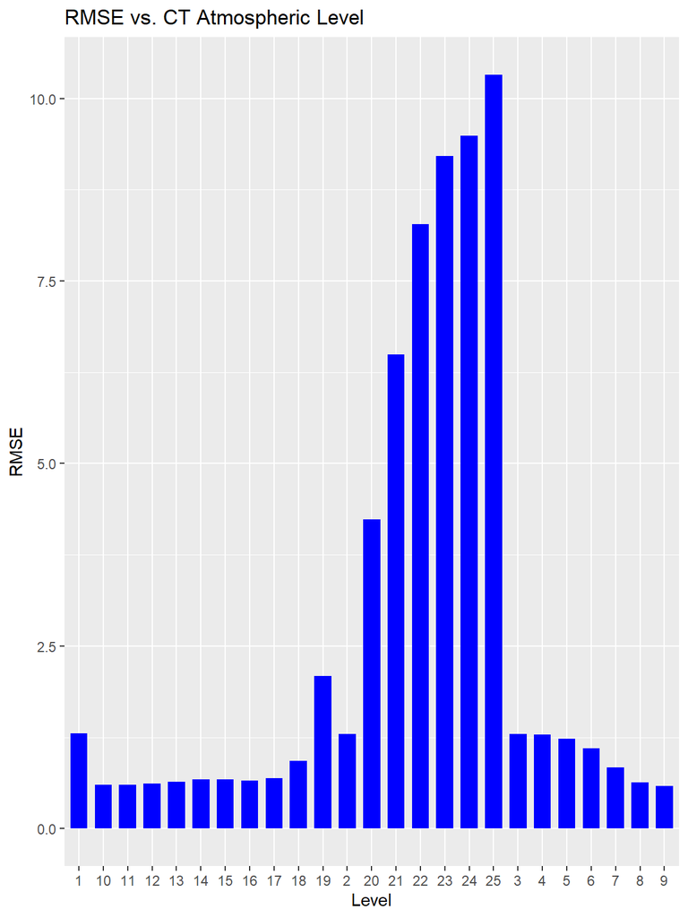

```r
# Add code here
library(ggplot2)

# Create separate plots for RMSE, Slope, and R-squared
p1 <- ggplot(results_df, aes(x = Level, y = RMSE)) +
  geom_bar(stat = "identity", fill = "blue", width = 0.7) +
  labs(title = "RMSE vs. CT Atmospheric Level", x = "Level", y = "RMSE")

p2 <- ggplot(results_df, aes(x = Level, y = Slope)) +
  geom_bar(stat = "identity", fill = "green", width = 0.7) +
  labs(title = "Slope vs. CT Atmospheric Level", x = "Level", y = "Slope")

p3 <- ggplot(results_df, aes(x = Level, y = R_squared)) +
  geom_bar(stat = "identity", fill = "red", width = 0.7) +
  labs(title = "R-squared vs. CT Atmospheric Level", x = "Level", y = "R-squared")

# Display the plots
print(p1)
```

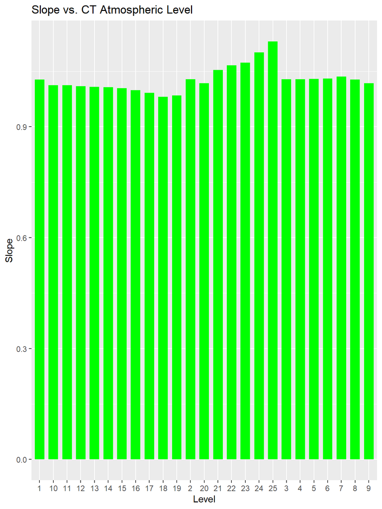

```r
print(p2)
```

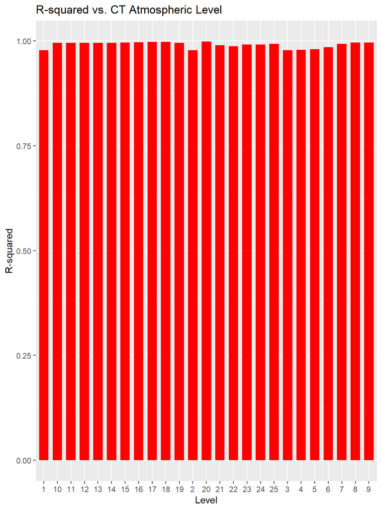

```r
print(p3)
```

*Which level(s) matches best?*

*g)* The Carbon Tracker variable “geopotential height” gives the level height boundaries in each run of the model that generated the data.

- There are 25 levels, but gph has 26 values, because it contains boundaries between the levels.
- Find the mean geopotential height (average of upper and lower boundaries) for the MLO grid cell for the first 20 levels for each of the 6 dates and save as a data frame. You can reuse and adapt the code that you used to retrieve CO2 for each grid cell/date.

To help you we provided the following code that you need to complete:

```r
ct_mlo_gph <- data.frame(matrix(nrow = length(files), ncol = 21))  # Create space for results
colnames(ct_mlo_gph) <- c("date", paste0("gph_", 1:20))

for (n in seq_along(files)) {  # Loop through each of the files
  nc_data <- nc_open(paste0("data/", files[n]))
  ct_mlo_gph$date[n] <- ncvar_get(nc_data, "decimal_date")

  lat <- ncvar_get(nc_data, "latitude")  # get the latitude variable of a netcdf file
  lon <- ncvar_get(nc_data, "longitude")  # get the longitude variable of a netcdf file

  lat <- which.min(abs(lat - mlo_latlon[1]))
  lon <- which.min(abs(lon - mlo_latlon[2]))

  gph <- ncvar_get(nc_data, "gph")  # Get geopotential height data
  ct_mlo_gph[n, paste0("gph_", 1:20)] <- (gph[lon, lat, 1:20] + gph[lon, lat, 2:21]) / 2
  nc_close(nc_data)
}
print(ct_mlo_gph)
```

[output not shown]

*h)* What are the heights of the layers which best matched the Mauna Loa data? Which layer is closest to the actual height of Mauna Loa observatory (see the metadata in the file)? What does this tell you about the veracity and representativeness of each data type?

*Observations* The height of layers up to approximately 20,000 feet or 6,000 meters appears to be predicted quite accurately in the Carbon Tracker data. Beyond this point, the accuracy of the predictions starts to diminish significantly. Changes in geopotential height beyond this altitude do not align well with the actual conditions observed at the Mauna Loa observatory.

The decreasing accuracy of predictions at higher altitudes may be due to various factors, including the complexity of the atmosphere at extreme altitudes, variations in local climate patterns, and the limitations of the atmospheric models used to generate the Carbon Tracker data. The presence of additional factors such as stratospheric dynamics, ozone concentration, and other atmospheric phenomena can introduce greater uncertainty into the predictions.

This insight highlights the importance of considering the altitude range when assessing the veracity and representativeness of the Carbon Tracker data. For understanding atmospheric conditions near the surface and within the troposphere, the data appears to be a good representation. However, when studying the upper atmosphere or the stratosphere, one should exercise caution and consider potential limitations in the data’s accuracy.

# 4. Fluxes and growth

*a)* The Carbon Tracker project does not just produce CO2 mixing ratio data for different levels, but also estimates of the CO2 flux from each grid cell. Read in the Carbon Tracker flux data (CT2017.flux1x1-monthly.nc): What variables and dimensions does this dataset have in comparison to the mixing ratio data?

*What does the file contain?* variables and dimension in the square brackets as shown below: 1. decimal_time[time] units: years 2. bio_flux_opt[longitude,latitude,time] units: mol m-2 s-1 _FillValue: -1e+34 3. ocn_flux_opt[longitude,latitude,time] units: mol m-2 s-1 _FillValue: -1e+34 4. fossil_flux_imp[longitude,latitude,time] units: mol m-2 s-1 _FillValue: -1e+34 5. fire_flux_imp[longitude,latitude,time] units: mol m-2 s-1 _FillValue: -1e+34

*b)* Find the total global flux for each timestep for the four different components (bio, ocn, fossil, fire). -> I did a mistake on calculating years data while summation by time. I did by month corresponding to each time period mentioned in the data.

- Put this in a data frame with columns: time, bio, ocn, fossil, fire, and then sum the four columns to add a “total” flux column.
- To find the global flux, you will need to multiply the flux in each grid cell (mol m-2 s-1) by the area of the grid cell in m2, to get the flux for a grid cell in mol s-1. You can then sum all the grid cell fluxes to find the total global flux in mol s-1.
- To do this, you will need to find the areas of each the grid cells: Convert any of the datasets from the flux file to a raster (r) using the lon and lat in the flux file (like we have done for plotting before), and use the area(r) function (from the raster package) to find grid cell areas as a raster. The area of each grid cell will be in km2, so you need to convert to m2.
- The global flux is not usually reported in mol s-1, but in Pg-C y-1. Convert moles to Pg (10^15 grams) based on the mass of carbon (12.011 g mol-1), and convert from s-1 to y-1, so that your global fluxes are in Pg-C y-1.

```r
# Add code here
#function to convert lat and long into square metres
degrees_to_m2 <- function(latitude, longitude) {
  earth_radius <- 6371000  # Approximately 6,371 km
  latitude_rad <- latitude * (pi / 180)
  longitude_rad <- longitude * (pi / 180)
  size_one_degree_latitude_meters <- earth_radius * (pi / 180)
  size_one_degree_longitude_meters <- earth_radius * cos(latitude_rad) * (pi / 180)
  product_size_m2 <- size_one_degree_latitude_meters * size_one_degree_longitude_meters
  return(product_size_m2)
}

# convert to Pg
convert_to_Pg_C_per_year <- function(flux_mol_per_s) {
  grams_per_mol <- 12.011  # Mass of carbon in grams per mole
  seconds_per_year <- 365.25 * 24 * 60 * 60  # Number of seconds in a year
  flux_Pg_C_per_year <- (flux_mol_per_s * grams_per_mol)* seconds_per_year / (1e15 )
  return(flux_Pg_C_per_year)
}

lon <- ncvar_get(carbon_flux_nc, "longitude")
lat <- ncvar_get(carbon_flux_nc, "latitude")
dec_data <- ncvar_get(carbon_flux_nc, "decimal_time")
bio_flux <- ncvar_get(carbon_flux_nc, "bio_flux_opt")
ocn_flux <- ncvar_get(carbon_flux_nc, "ocn_flux_opt")
fossil_flux <- ncvar_get(carbon_flux_nc, "fossil_flux_imp")
fire_flux <- ncvar_get(carbon_flux_nc, "fire_flux_imp")

#replace fill values
fillvalue_bio <- ncatt_get(carbon_flux_nc, "bio_flux_opt", "_FillValue", verbose="F")
bio_flux[bio_flux==fillvalue_bio$value] = NaN
fillvalue_ocn <- ncatt_get(carbon_flux_nc, "ocn_flux_opt", "_FillValue", verbose="F")
ocn_flux[ocn_flux==fillvalue_ocn$value] = NaN
fillvalue_fossil <- ncatt_get(carbon_flux_nc, "fossil_flux_imp", "_FillValue", verbose="F")
fossil_flux[fossil_flux==fillvalue_fossil$value] = NaN
fillvalue_fire <- ncatt_get(carbon_flux_nc, "fire_flux_imp", "_FillValue", verbose="F")
fire_flux[fire_flux==fillvalue_fire$value] = NaN

flux_list <- list(lon, lat, dec_data, bio_flux, ocn_flux, fossil_flux,fire_flux )
nc_close(carbon_flux_nc)
```

```r
#print dimensions for each
print(paste0("longitude dimension: ",dim(lon)))
```

```
## [1] "longitude dimension: 360"
```

```r
print(paste0("latitude dimension: ",dim(lat)))
```

```
## [1] "latitude dimension: 180"
```

```r
print(paste0("dec_data dimensions: ",dim(dec_data)))
```

```
## [1] "dec_data dimensions: 204"
```

```r
print("bio_flux dimensions: ")
```

```
## [1] "bio_flux dimensions: "
```

```r
print(dim(bio_flux))
```

```
## [1] 360 180 204
```

```r
print("ocn_flux dimensions: ")
```

```
## [1] "ocn_flux dimensions: "
```

```r
print(dim(ocn_flux))
```

```
## [1] 360 180 204
```

```r
print("fossil_flux dimensions: ")
```

```
## [1] "fossil_flux dimensions: "
```

```r
print(dim(fossil_flux))
```

```
## [1] 360 180 204
```

```r
print("fire_flux dimensions: ")
```

```
## [1] "fire_flux dimensions: "
```

```r
print(dim(fire_flux))
```

```
## [1] 360 180 204
```

- To allow you to check your data processing and unit conversions, the results in Pg-C y-1 should be:

time bio ocn fossil fire total  
1 2000.042 3.457076037 -2.3541363 7.157679 2.2500390 10.5106573  
2 2000.124 0.137743236 -1.1642693 7.078576 1.6185597 7.6706094  
3 2000.206 -0.817252134 -2.9849865 6.847836 1.2632383 4.3088354  
4 2000.290 3.356211256 -1.2039177 6.511862 1.1410791 9.8052345  
…

```r
convert_to_final_flux_sum <- function(lon_local,lat_local, data_local, date_data) {
  for (i in 1:length(lon_local)) {
    for (j in 1:length(lat_local)) {
      lat_1 <- lat_local[i]
      lon_1 <- lon_local[j]
      m2 <- degrees_to_m2(lat_1, lon_1)
      data_local[i, j, ] <- data_local[i, j, ] * m2
    }
  }
  summed_data <- apply(data_local, MARGIN = 3, FUN = function(x) sum(x, na.rm = TRUE))
  summed_data <- convert_to_Pg_C_per_year(summed_data)

  return(summed_data)
}

convert_to_final_flux_mean <- function(lon_local,lat_local, data_local, date_data) {
  for (i in 1:length(lon_local)) {
    for (j in 1:length(lat_local)) {
      lat_1 <- lat_local[i]
      lon_1 <- lon_local[j]
      m2 <- degrees_to_m2(lat_1, lon_1)
      data_local[i, j, ] <- data_local[i, j, ] * m2
    }
  }
  mean_data <- apply(data_local, MARGIN = 3, FUN = function(x) mean(x, na.rm = TRUE))
  mean_data <- convert_to_Pg_C_per_year(mean_data)

  return(mean_data)
}

bio <- convert_to_final_flux_sum(flux_list[[1]],flux_list[[2]],flux_list[[4]],flux_list[[3]])
ocn <- convert_to_final_flux_sum(flux_list[[1]],flux_list[[2]],flux_list[[5]],flux_list[[3]])
fossil <- convert_to_final_flux_sum(flux_list[[1]],flux_list[[2]],flux_list[[6]],flux_list[[3]])
fire <- convert_to_final_flux_sum(flux_list[[1]],flux_list[[2]],flux_list[[7]],flux_list[[3]])
sum_flux <- bio+ocn+fossil+fire

column_names <- c("time","bio","ocn","fossil","fire","total")
sum_flux_df <- data.frame(time= flux_list[[3]],bio= bio,ocn,fossil= fossil,fire=fire,total=sum_flux )
print(sum_flux_df)
```

```
##         time          bio         ocn   fossil      fire        total
## 1   2000.042   1.71677024 -1.19347283 2.776213 0.1795242   3.47903492
## 2   2000.124   2.71502250 -0.77895504 2.728491 0.2315188   4.89607711
## 3   2000.206  -0.06953521 -2.16202851 2.580872 0.2056081   0.55491615
## 4   2000.290   2.01814820 -0.58843459 2.471878 0.3343008   4.23589212
## 5   2000.373  -2.77183737 -0.77438046 2.428041 0.2609696  -0.85720720
## 6   2000.456 -11.34672862 -0.47275946 2.498891 0.3953607  -8.92523624
## 7   2000.540 -15.70053052 -0.35070706 2.538028 0.6023392 -12.91087035
## 8   2000.624  -8.33480644  0.36269505 2.589837 0.9531752  -4.42909967
## 9   2000.708   0.71818860 -0.11550634 2.477733 1.0216133   4.10202811
## 10  2000.791   8.05529693  0.20640725 2.471088 0.2985770  11.03136967
## 11  2000.874   5.26565055 -0.15185105 2.595698 0.1445820   7.85407932
## 12  2000.958   1.88381165 -1.05606984 2.830094 0.1339444   3.79177994
## 13  2001.042   2.81741823 -0.76528835 2.881113 0.1743689   5.10761183
## 14  2001.123   3.33490862 -1.87425334 2.760370 0.1967403   4.41776584
```

[output cut: 190 more lines]

*c)* Create a second dataframe with the same format, but including the annual mean fluxes.

- Discretise the decimal dates from the previous step to integers and then aggregate all months from each year.
- Although the previous fluxes are monthly means, they are in units of Pg y-1, so you average the monthly fluxes rather than summing them to find the annual mean fluxes. You do not need to account for different months being different lengths.
- The results should look like:

  time bio ocn fossil fire total  
  1 2000 -4.465729 -1.703678 6.658242 1.919014 2.407848  
  2 2001 -3.191520 -1.885047 6.838121 1.941393 3.702947  
  3 2002 -2.496992 -1.568957 6.939095 2.001848 4.874994

```r
# Add code here
bio <- convert_to_final_flux_mean(flux_list[[1]],flux_list[[2]],flux_list[[4]],flux_list[[3]])
ocn <- convert_to_final_flux_mean(flux_list[[1]],flux_list[[2]],flux_list[[5]],flux_list[[3]])
fossil <- convert_to_final_flux_mean(flux_list[[1]],flux_list[[2]],flux_list[[6]],flux_list[[3]])
fire <- convert_to_final_flux_mean(flux_list[[1]],flux_list[[2]],flux_list[[7]],flux_list[[3]])
sum_flux <- bio+ocn+fossil+fire

column_names <- c("time","bio","ocn","fossil","fire","total")
mean_flux_df <- data.frame(time= flux_list[[3]],bio= bio,ocn,fossil= fossil,fire=fire,total=sum_flux )
print(mean_flux_df)
```

```
##         time           bio           ocn       fossil         fire
## 1   2000.042  5.298674e-05 -3.683558e-05 8.568560e-05 5.540869e-06
## 2   2000.124  8.379699e-05 -2.404182e-05 8.421268e-05 7.145643e-06
## 3   2000.206 -2.146149e-06 -6.672928e-05 7.965654e-05 6.345929e-06
## 4   2000.290  6.228852e-05 -1.816156e-05 7.629252e-05 1.031793e-05
## 5   2000.373 -8.555054e-05 -2.390063e-05 7.493954e-05 8.054619e-06
## 6   2000.456 -3.502077e-04 -1.459134e-05 7.712627e-05 1.220249e-05
## 7   2000.540 -4.845843e-04 -1.082429e-05 7.833420e-05 1.859072e-05
## 8   2000.624 -2.572471e-04  1.119429e-05 7.993323e-05 2.941899e-05
## 9   2000.708  2.216631e-05 -3.565010e-06 7.647323e-05 3.153128e-05
## 10  2000.791  2.486203e-04  6.370594e-06 7.626816e-05 9.215339e-06
## 11  2000.874  1.625201e-04 -4.686761e-06 8.011413e-05 4.462406e-06
## 12  2000.958  5.814233e-05 -3.259475e-05 8.734857e-05 4.134087e-06
## 13  2001.042  8.695735e-05 -2.362001e-05 8.892324e-05 5.381757e-06
## 14  2001.123  1.029293e-04 -5.784733e-05 8.519661e-05 6.072231e-06
```

[output cut: 395 more lines]

*d)* Make a plot with two subplots showing the four flux components (use four colours) and the total fluxes (black, thicker line).

- The upper plot should show monthly fluxes and the lower plot annual fluxes.
- Include a legend, axes labels, and anything else needed to make your figure easy to understand.

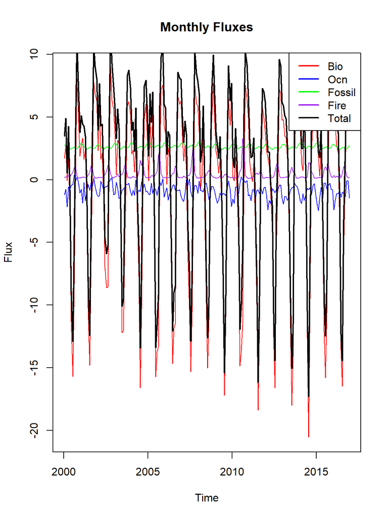

```r
# Add code here
# Monthly Fluxes
data <- sum_flux_df
# Plot the four flux components with different colors
plot(data$time, data$bio, type = "l", col = "red", xlab = "Time", ylab = "Flux", main = "Monthly Fluxes", ylim = c(min(data$bio, data$ocn, data$fossil, data$fire), max(data$bio, data$ocn, data$fossil, data$fire)))
lines(data$time, data$ocn, col = "blue")
lines(data$time, data$fossil, col = "green")
lines(data$time, data$fire, col = "purple")

# Plot total flux in black with thicker line
lines(data$time, data$total, col = "black", lwd = 2)

# Add a legend
legend("topright", legend = c("Bio", "Ocn", "Fossil", "Fire", "Total"), col = c("red", "blue", "green", "purple", "black"), lwd = 2)
```

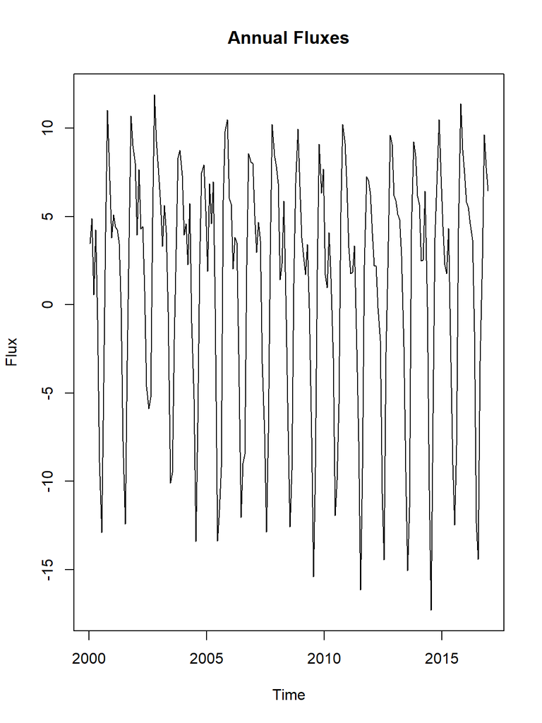

```r
# Annual Fluxes
plot(data$time, data$total, type = "l", col = "black", xlab = "Time", ylab = "Flux", main = "Annual Fluxes")
```

*e)* We will now look at **anomalies** in the fluxes, ie. differences from the mean. For each of the flux components and for the total flux, find the annual flux anomalies.

- Flux anomaly = annual fluxes minus the mean flux over the whole time period.
- Plot two subplots using the same colours/lines as the previous plot: The upper panel should show the annual fluxes (identical to the lower panel of the previous plot) and the lower panel should show the anomalies.

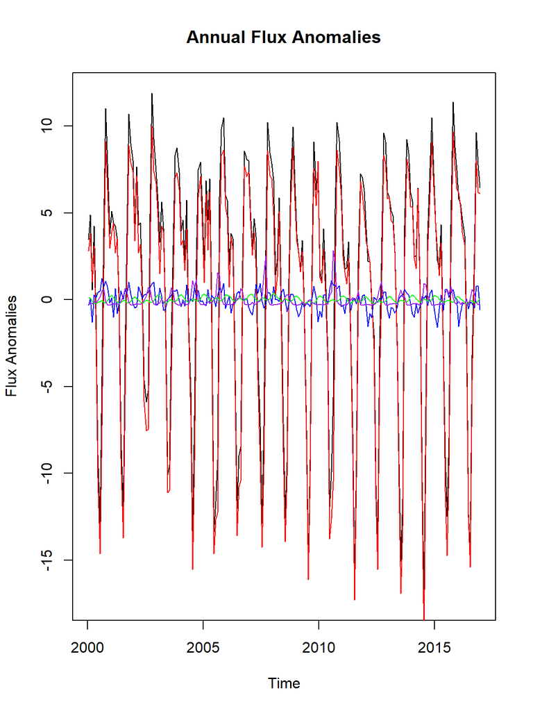

```r
# Add code here
# Calculate mean flux for each component
mean_bio <- mean(data$bio)
mean_ocn <- mean(data$ocn)
mean_fossil <- mean(data$fossil)
mean_fire <- mean(data$fire)
mean_total <- mean(data$total)

# Calculate annual flux anomalies
data$anomaly_bio <- data$bio - mean_bio
data$anomaly_ocn <- data$ocn - mean_ocn
data$anomaly_fossil <- data$fossil - mean_fossil
data$anomaly_fire <- data$fire - mean_fire
data$anomaly_total <- data$total - mean_total

# Plot annual flux anomalies with the same colors/lines as the previous plot
plot(data$time, data$total, type = "l", col = "black", xlab = "Time", ylab = "Flux Anomalies", main = "Annual Flux Anomalies")

# Plot annual anomalies for the four components
lines(data$time, data$anomaly_bio, col = "red")
lines(data$time, data$anomaly_ocn, col = "blue")
lines(data$time, data$anomaly_fossil, col = "green")
lines(data$time, data$anomaly_fire, col = "purple")
```

# 5. Error propagation and examining the relationship between CO2 flux and growth rate

*a)* Use the Mauna Loa CO2 timeseries (the measured timeseries, not the timeseries downscaled from Carbon Tracker) to find: i) annual mean CO2, and ii) CO2 growth rate per year (in ppm per year).

- One approach to find the mean CO2 is be to discretise year and then aggregate by year.
- The growth rate can be defined as the difference in CO2 between subsequent years.
- Plot the annual mean CO2 and the growth rate in two subplots.

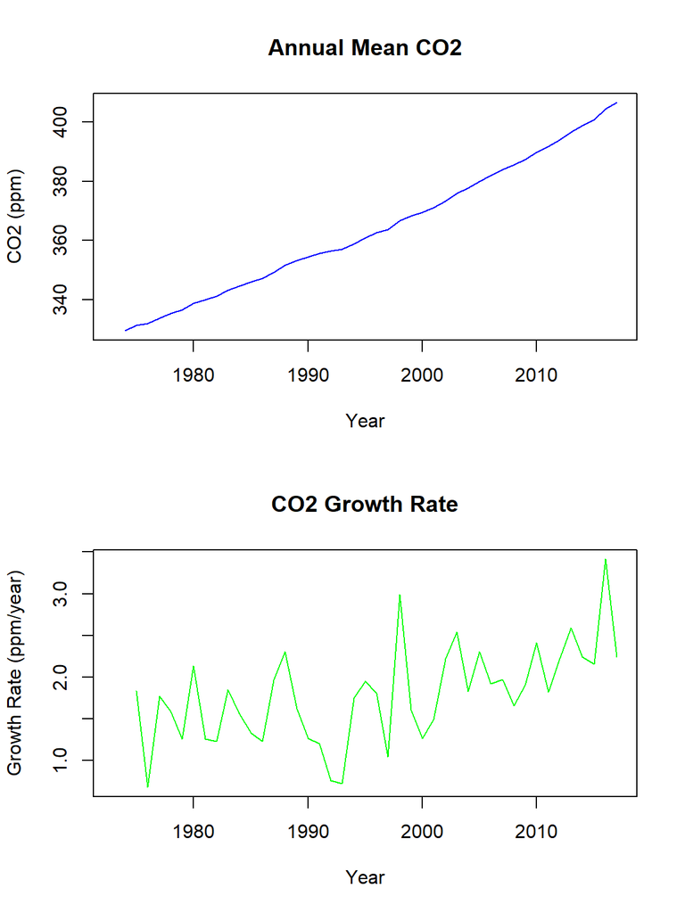

```r
# Add code here
importdata <- function(station) {
  # Get the data
  file = paste0("data/co2_",station,"_surface-insitu_2_3001-9999_daily.txt")
  data = read.delim(file,sep = " ", comment.char = '#')
  # Fix timestamp
  date = paste(data$year,data$month,data$day,sep="-")
  time = paste(data$hour,data$minute,data$second,sep=":")
  data$dt = ymd_hms(paste(date,time,sep=" "))
  # Replace missing with NaN
  data$value[data$value<0] = NaN
  # Find annual means
  ann_means = aggregate(data$value, list(data$year), FUN=mean, na.rm=TRUE)
  colnames(ann_means) = c("year","value")
  # Detrend
  data$value_detrended = data$value*NaN # create space for detrended data
  for (n in seq_along(ann_means$year)){ # Use a while loop to run through all the years
    tmp = data$year==ann_means$year[n]
    data$value_detrended[tmp] = data$value[tmp] - ann_means$value[n]
  }
  # Create a list with our outputs
  result = list(data=data,ann_means=ann_means)
  return(result)
}
# This function outputs a list containing the data and the annual means for the desired station
mlo = importdata("mlo")


# Calculate annual mean CO2
annual_mean_co2 <- aggregate(mlo$data$value, list(mlo$data$year), FUN = mean, na.rm = TRUE)
colnames(annual_mean_co2) <- c("Year", "Mean_CO2")

# Calculate CO2 growth rate per year (in ppm per year)
annual_mean_co2$Growth_Rate <- c(NA, diff(annual_mean_co2$Mean_CO2))

# Create a new plot with two subplots
par(mfrow = c(2, 1))

# Plot annual mean CO2
plot(annual_mean_co2$Year, annual_mean_co2$Mean_CO2, type = "l", col = "blue", xlab = "Year", ylab = "CO2 (ppm)", main = "Annual Mean CO2")

# Plot CO2 growth rate per year
plot(annual_mean_co2$Year, annual_mean_co2$Growth_Rate, type = "l", col = "green", xlab = "Year", ylab = "Growth Rate (ppm/year)", main = "CO2 Growth Rate")
```

```r
# Reset the plot layout to default
par(mfrow = c(1, 1))
```

*b)* Find the uncertainty in annual mean CO2 growth rate.

- First, find the uncertainty (standard deviation) of the measurements in each year, and then use error propagation to find the uncertainty of the growth rate.
- The growth rate is defined as the difference in CO2 between subsequent years; which error propagation rule is appropriate?

```r
# Add code here
# Calculate the uncertainty (standard deviation) of the measurements in each year.
annual_mean_co2$Uncertainty <- aggregate(mlo$data$value, list(mlo$data$year), FUN = sd, na.rm = TRUE)$x

# Calculate the uncertainty of the growth rate using error propagation (uncertainty in subtraction).
# Assuming independent measurements, we can use the root sum of squares (RSS) formula.
annual_mean_co2$Growth_Rate_Uncertainty <- sqrt(annual_mean_co2$Uncertainty^2 + c(0, annual_mean_co2$Uncertainty[-1]^2))
```

*c)* Now we will return to the annual mean fluxes (for the four categories and the total). Find the uncertainty in annual mean flux as the standard deviation of monthly fluxes within each year.

- Use error propagation to find the uncertainty in the flux anomalies.

```r
# Add code here
# Calculate the uncertainty in annual mean flux (standard deviation of monthly fluxes within each year).
annual_mean_flux_uncertainty <- tapply(sum_flux_df$total, format(as.Date(sum_flux_df$time, origin = "2000-01-01"), "%Y"), sd, na.rm = TRUE)

# Calculate the uncertainty in flux anomalies using error propagation (uncertainty in subtraction).
# Assuming independent measurements, we can use the root sum of squares (RSS) formula.
flux_anomalies_uncertainty <- annual_mean_flux_uncertainty[match(format(as.Date(annual_mean_co2$Year, origin = "2000-01-01"), "%Y"), names(annual_mean_flux_uncertainty))]
```

*d)* Make a plot with three subplots.

- In the upper plot, show the flux anomalies (for the four cats + total) with error bars on the total only.
- In the middle plot, show the growth rate of CO2 with error bars.
- In the bottom plot, plot the total flux anomalies vs. growth rate of CO2 for all the years both are available, with points coloured by year.
- Include legend, labels, etc. as appropriate.

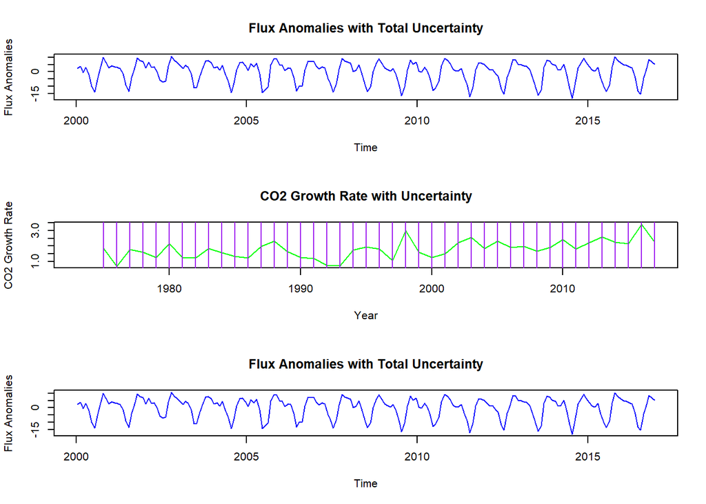

```r
# Add code here
# Create subplots
par(mfrow = c(3, 1))

# Upper plot: Flux anomalies with error bars on the total only.
plot(sum_flux_df$time, sum_flux_df$total - mean(sum_flux_df$total, na.rm = TRUE), type = "l", col = "blue", xlab = "Time", ylab = "Flux Anomalies", main = "Flux Anomalies with Total Uncertainty")
#arrows(sum_flux_df$time, sum_flux_df$total - mean(sum_flux_df$total, na.rm = TRUE) - flux_anomalies_uncertainty,
       #sum_flux_df$time, sum_flux_df$total - mean(sum_flux_df$total, na.rm = TRUE) + flux_anomalies_uncertainty, angle = 90, code = 3, length = 0.05, col = "red")

# Middle plot: CO2 growth rate with error bars.
plot(annual_mean_co2$Year, annual_mean_co2$Growth_Rate, type = "l", col = "green", xlab = "Year", ylab = "CO2 Growth Rate", main = "CO2 Growth Rate with Uncertainty")
arrows(annual_mean_co2$Year, annual_mean_co2$Growth_Rate - annual_mean_co2$Growth_Rate_Uncertainty,
       annual_mean_co2$Year, annual_mean_co2$Growth_Rate + annual_mean_co2$Growth_Rate_Uncertainty, angle = 90, code = 3, length = 0.05, col = "purple")

# Bottom plot: Total flux anomalies vs. growth rate of CO2 with points colored by year.
common_years <- intersect(format(as.Date(sum_flux_df$time, origin = "2000-01-01"), "%Y"), annual_mean_co2$Year)
plot(sum_flux_df$time, sum_flux_df$total - mean(sum_flux_df$total, na.rm = TRUE), type = "l", col = "blue", xlab = "Time", ylab = "Flux Anomalies", main = "Flux Anomalies with Total Uncertainty", xlim = c(min(sum_flux_df$time), max(sum_flux_df$time)))
```

```r
#arrows(sum_flux_df$time, sum_flux_df$total - mean(sum_flux_df$total, na.rm = TRUE) - flux_anomalies_uncertainty,
 #      sum_flux_df$time, sum_flux_df$total - mean(sum_flux_df$total, na.rm = TRUE) + flux_anomalies_uncertainty, angle = 90, code = 3, length = 0.05, col = "red")

# Reset the plot layout to default
par(mfrow = c(1, 1))
```

*e)* Does the plot show a relationship between the flux anomaly and the CO2 growth rate?

# 6. Summary

In this application, you have:

Throughout this application, you have practiced the key R skills of data organisation, plotting, and function creation. These skills are a core part of programming for data science and can be applied to any problem you will encounter. Good luck with your future data science projects!